# Lab 3 : ggplot

Jeremy Morris

2/20/2019

# Introduction to ggplot2

“ggplot()” is the generic function call. A plot can include any of the following objects.

- `ggplot` - the primary building block of a chart. By itself only generates a blank chart.
- `aes` - short for ‘aesthetic mapping’. This function tells the plot how to map data to different portions of the chart (e.g. x-axis,y-axis,fill,etc.)
- `geom` - short for ‘geometric object’. These are the actual charts,a short list of options follows.
  - `geom_point` - scatterplot
  - `geom_bar` - bar chart
  - `geom_line` - line chart
- `labs` - chart labels and titles
- `coord` - functions to modify the coordinate space. The most commonly used is `coord_flip` to rotate a chart 90 degrees.
- `facet` - these control how many charts are shown. We will cover these in more detail in the next lab.
- `theme` - functions to modify the overall look and feel over the chart.

The great thing about ggplot is that it allows you to control nearly every aspect of a data visualization. Because there is so much control,there is also a learning curve associated with that level of control.

The basic structure of a ggplot call is to first call the ggplot function and then add the different components to the chart. The aesthetic mappings can be added when `ggplot` is called or they can be added in the individual geometric objects. If added in the `ggplot` call,these aesthetic mappings will be used in all `geom` functions. You would add them to the `geom` function if you wanted to override the settings in `ggplot`.

### mtcars | weight vs. miles per gallon

In this example,we have a basic `ggplot` call with data and aesthetic mappings in the `ggplot` function.

```r
ggplot(mtcars,aes(x = wt,y = mpg)) +
    geom_point()
```

[output not shown]

```r
ggplot(mtcars) +
    geom_point(aes(x = wt,y = mpg))
```

[output not shown]

If you want to get very specific,the data used can also be added at the `geom` level. This allows you to build a visualization on multiple data sets (if that’s something you want to do). Going forward we will likely specify data and aesthetic mappings in the `ggplot` function but wanted to point out that there is some flexibility with how/where you specify those things.

```r
ggplot() +
    geom_point(aes(x = wt,y = mpg),data=mtcars)
```

[output not shown]

### heightweight | height vs. age

- df.heightweight is an object of type tibble
- it has 236 observations and 5 variables
- variables can be accessed by the convention “df.heightweight$ageYear”
- variables have different types themselves,which costrain how we can visualize them effectively

```r
df.heightweight <- read_csv(here('_data','heightweight.csv'))
df.heightweight
```

```
## # A tibble: 236 × 5
##    sex   ageYear ageMonth heightIn weightLb
##    <chr>   <dbl>    <dbl>    <dbl>    <dbl>
##  1 f        11.9      143     56.3     85
##  2 f        12.9      155     62.3    105
##  3 f        12.8      153     63.3    108
##  4 f        13.4      161     59       92
##  5 f        15.9      191     62.5    112.
##  6 f        14.2      171     62.5    112
##  7 f        15.4      185     59      104
##  8 f        11.8      142     56.5     69
##  9 f        13.3      160     62       94.5
## 10 f        11.7      140     53.8     68.5
## # … with 226 more rows
```

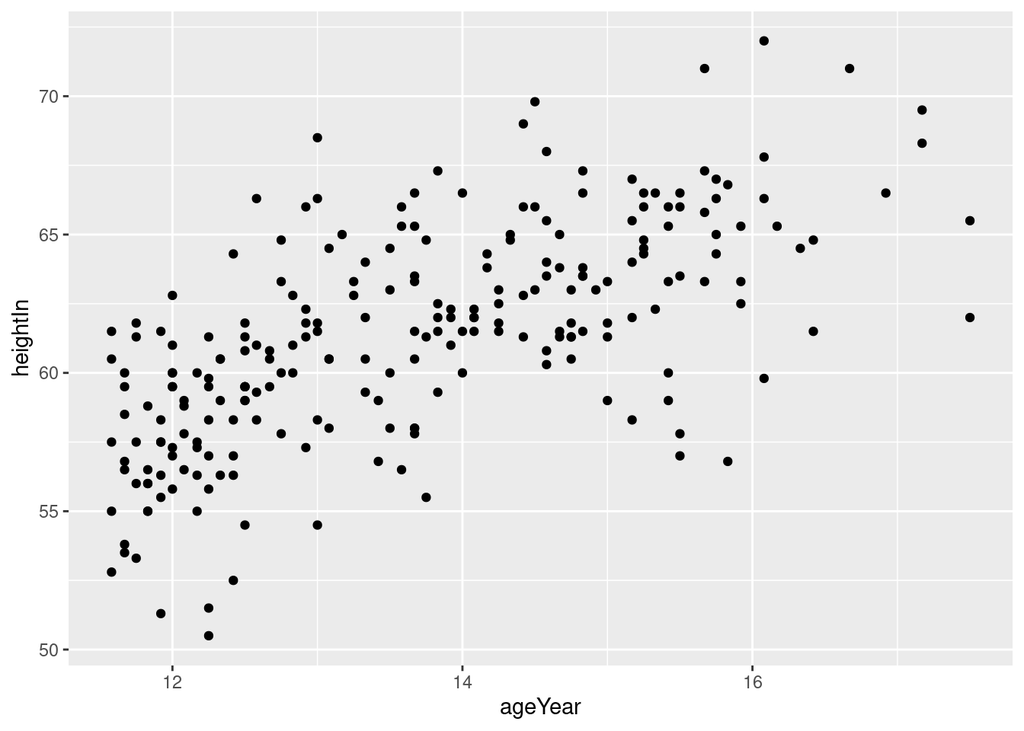

```r
ggplot(df.heightweight,aes(x = ageYear,y = heightIn)) +
  geom_point()
```

- In summary: Our objective is similar to that in the previous example. However,we are using a different dataset (heightweight) and are interested in the relationship between height and age.

### heightweight | height vs. age | include average height as reference

Add the average height to the plot for the reader’s reference. Note that we’re adding a second `geom` to the chart and even overriding the aesthetic mapping. This is a good example of how to add extra/aggregated data to a chart.

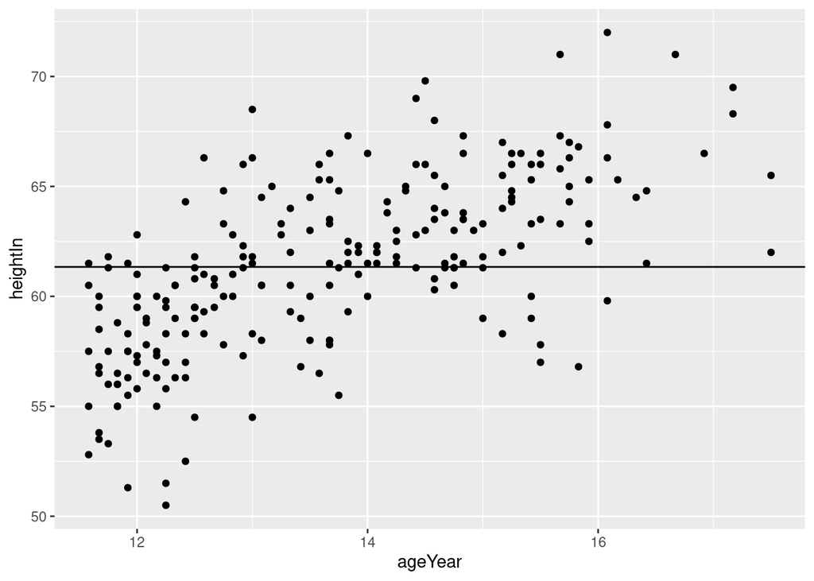

```r
ggplot(df.heightweight,aes(x = ageYear,y = heightIn)) +
  geom_point() +
  geom_hline(yintercept=mean(df.heightweight$heightIn))
```

### heightweight | height vs. age by gender

In this example,we add the ‘color’ aesthetic to the chart. You can see that `ggplot` automatically recognizes the different levels in the ‘sex’ variable and colors them differently.

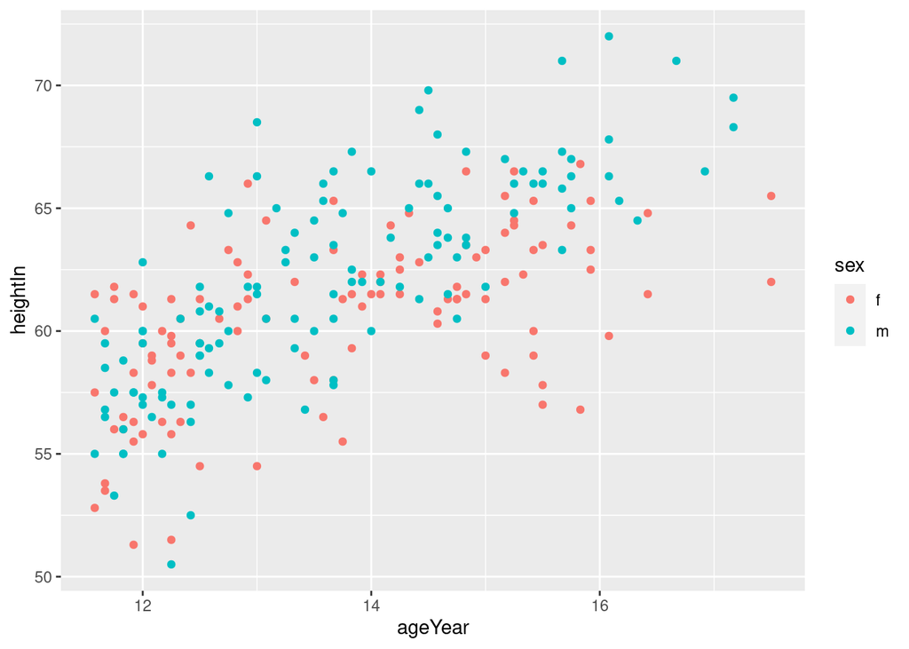

```r
ggplot(df.heightweight,aes(x = ageYear,y = heightIn,colour = sex)) +
  geom_point()
```

If we want a simple bar chart showing the average height by sex,we first pre-process the data calculating the average we want and then use `geom_col`.

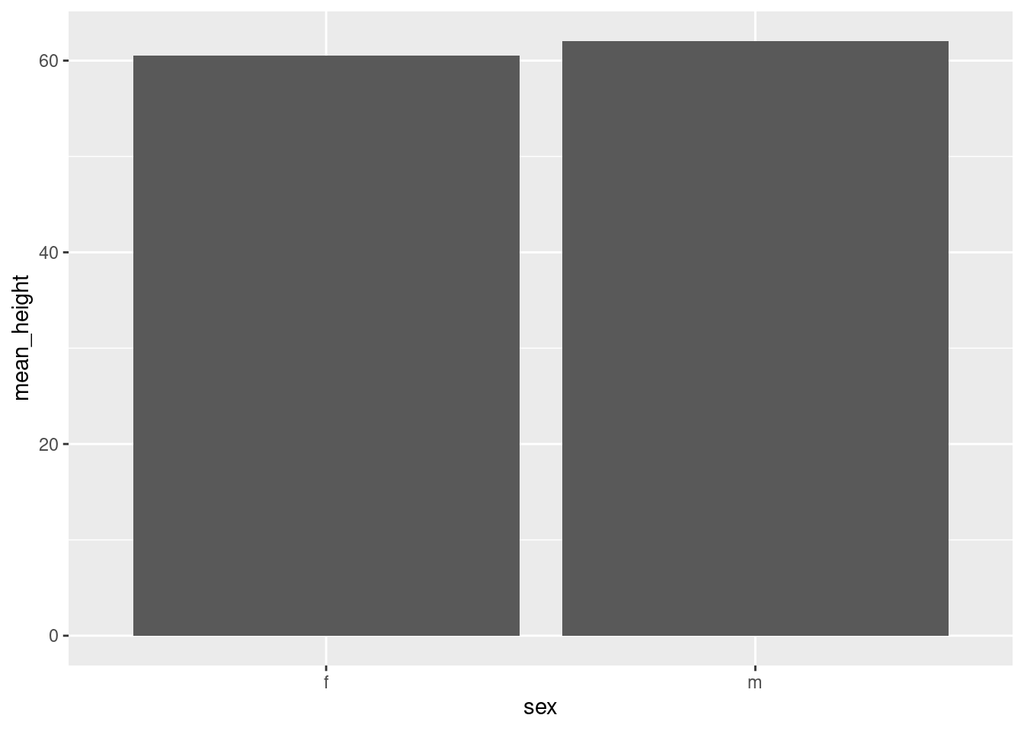

```r
by_sex <- df.heightweight %>% group_by(sex) %>% summarise(mean_height=mean(heightIn))
ggplot(by_sex) +
  geom_col(aes(x=sex,y=mean_height))
```

Not a super helpful chart,but it illustrates how to make a bar chart. We could also look at a boxplot for the same data to look at the distribution of values. In this example,we dress up the chart a little with some color and an added theme to make it look a little cleaner.

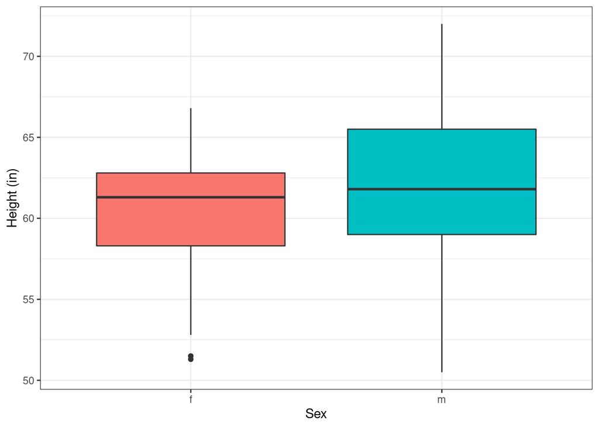

```r
ggplot(df.heightweight) +                          # specify the data set
  geom_boxplot(aes(x=sex,y=heightIn,fill=sex)) +   # setup a box plot with aesthetic mappings
  theme_bw() +                                     # use a different theme
  labs(x='Sex',y='Height (in)') +                  # add labels to x and y axes
  theme(legend.position='none')                    # remove the legend
```

We can also look at a density plot for each using the fill aesthetic and alpha blending to make a good looking chart. Note that we leave the legend on this one because `sex` doesn’t show up on an axis.

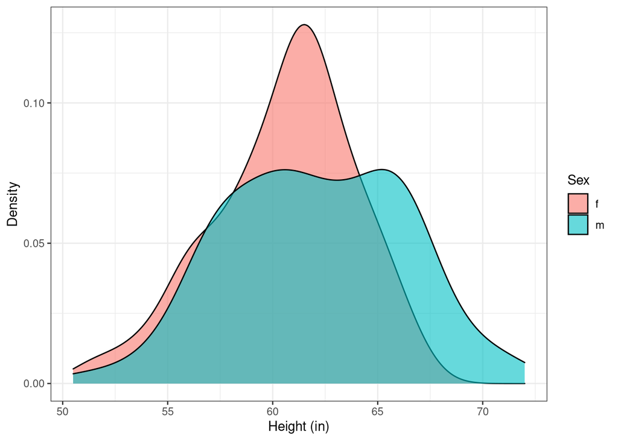

```r
ggplot(df.heightweight) +
  geom_density(aes(x=heightIn,fill=sex),alpha=0.6) +
  labs(x='Height (in)',y='Density',fill='Sex') +
  theme_bw()
```

### heightweight | height vs. age by weight

In this example,we see a continuous variable specified for the color aesthetic and note that `ggplot` uses a continuous color scale.

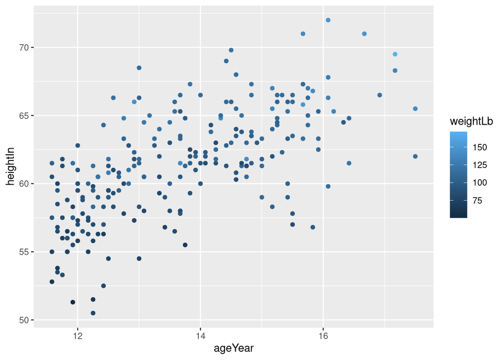

```r
ggplot(df.heightweight,aes(x = ageYear,y = heightIn,colour = weightLb)) +
  geom_point()
```

Here,we modify the size of the points using a static value.

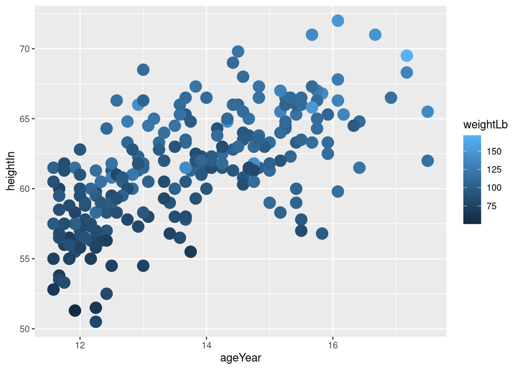

```r
ggplot(df.heightweight,aes(x = ageYear,y = heightIn,colour = weightLb)) +
  geom_point(size = 5)
```

Now the points remain the same size but we add transparency.

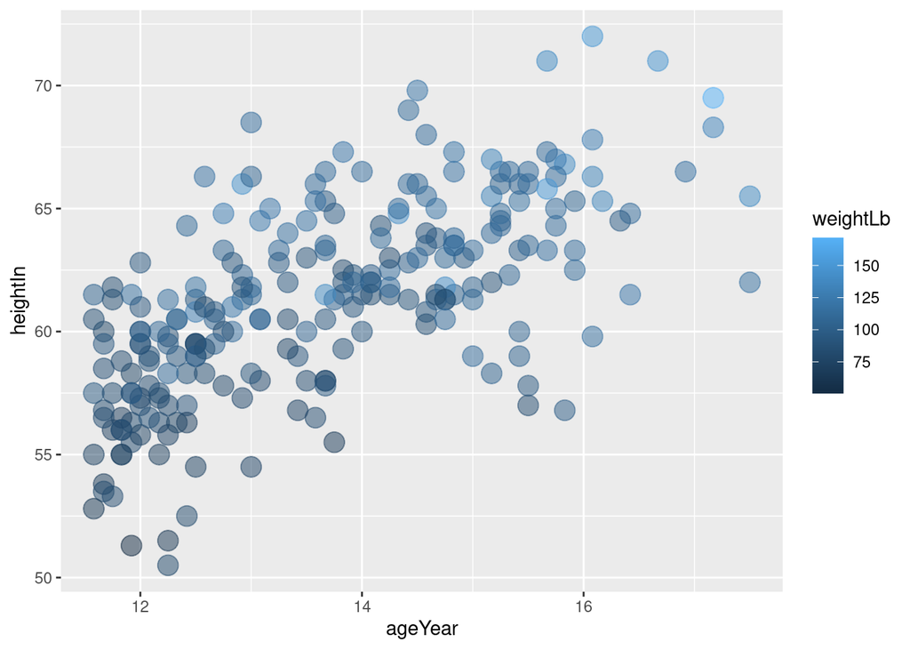

```r
ggplot(df.heightweight,aes(x = ageYear,y = heightIn,colour = weightLb)) +
  geom_point(size = 5,alpha = 0.5)
```

### Create line graph from text - step by step

```r
df_line_graph <- read_csv(here('_data','line.csv'))
df_line_graph
```

```
## # A tibble: 24 × 4
##    month monthNum volume type
##    <chr>    <dbl>  <dbl> <chr>
##  1 Jan          1    161 received
##  2 Feb          2    185 received
##  3 Mar          3    242 received
##  4 Apr          4    150 received
##  5 May          5    181 received
##  6 Jun          6    162 received
##  7 Jul          7    133 received
##  8 Aug          8    203 received
##  9 Sep          9    161 received
## 10 Oct         10    140 received
## # … with 14 more rows
```

basic line graph

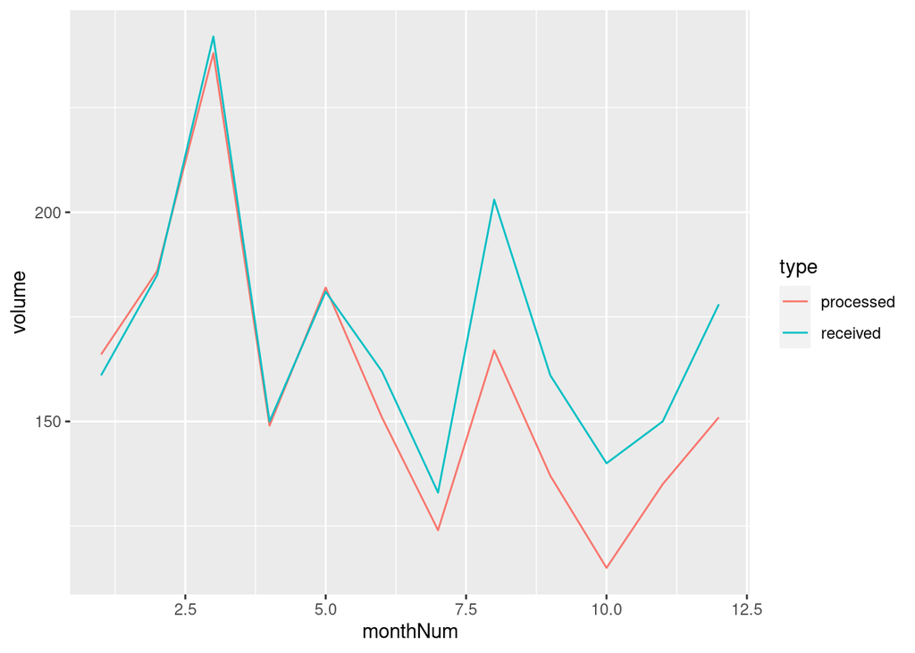

```r
ggplot(df_line_graph,aes(x=monthNum,y = volume,colour=type)) +
  geom_line()
```

remove gridelines

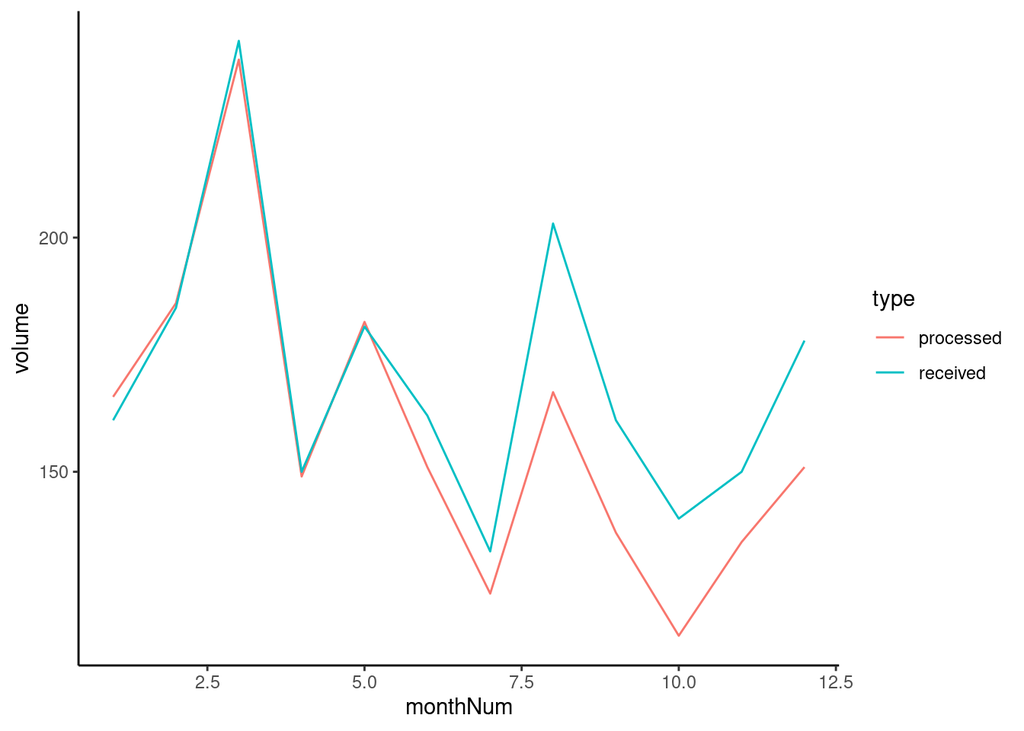

```r
ggplot(df_line_graph,aes(x=monthNum,y = volume,colour=type)) +
  geom_line() +
  theme_classic()   ## This theme removes a lot of the unneeded items
```

add points to follow example from text

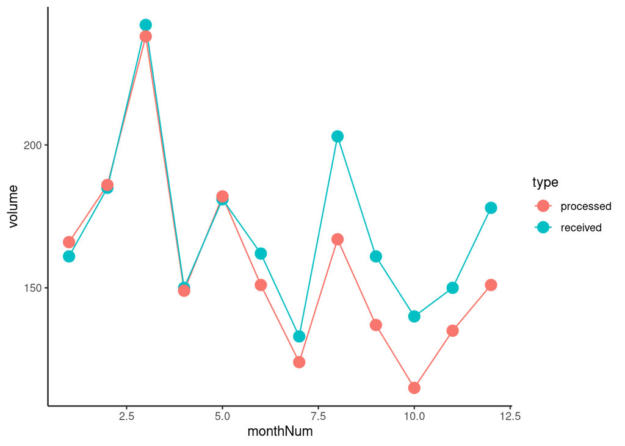

```r
ggplot(df_line_graph,aes(x = monthNum,y = volume,colour = type)) +
  geom_line() +
  theme_classic() +
  geom_point(size = 4)   ## adds points and sets the size
```

Fix the x-axis,note that some data work needed to get the names of the months.

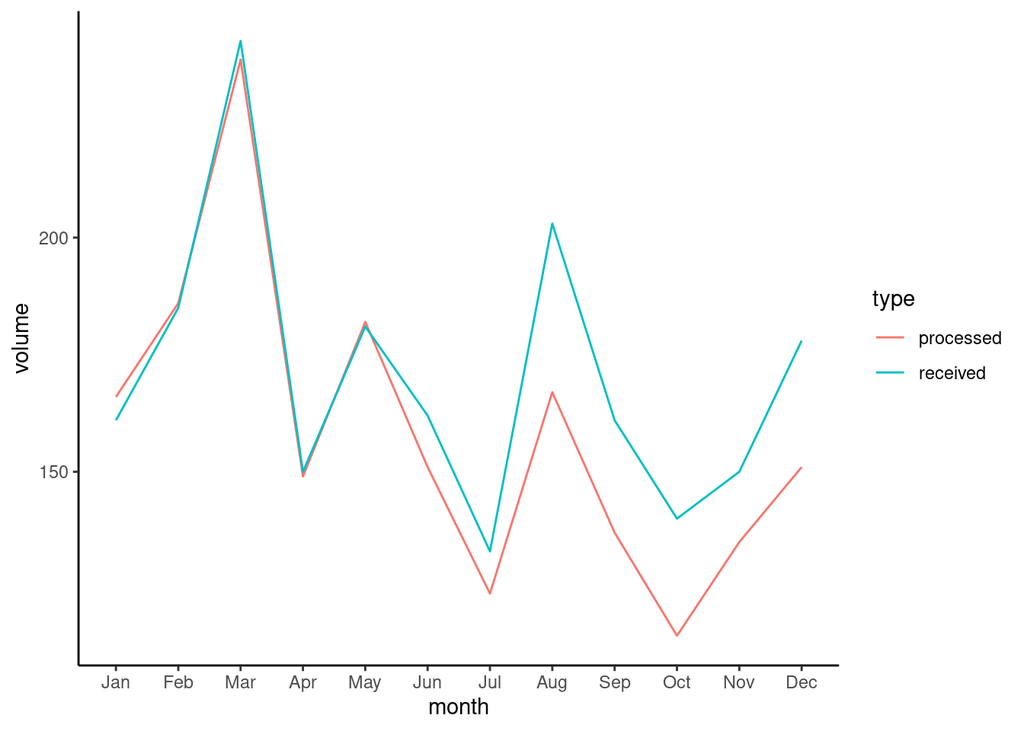

```r
ordered.month.list <- unique(as.character(df_line_graph$month))
df_line_graph$month <- factor(df_line_graph$month,levels=ordered.month.list)

ggplot(df_line_graph,aes(x = month,y = volume,colour = type,group = type)) +
  geom_line() +
  theme_classic()
```

Label lines directly,remove legend.

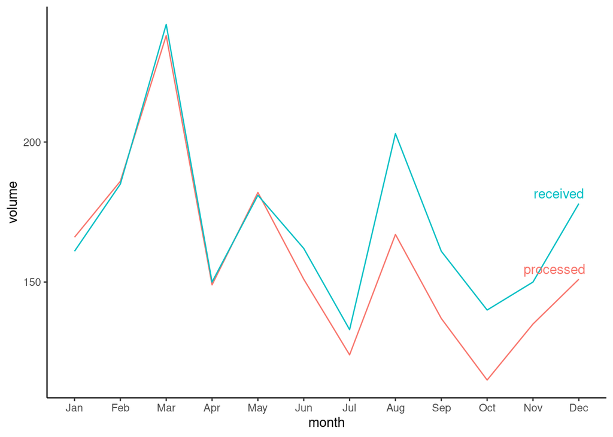

```r
data_labels <- df_line_graph %>% filter(month == 'Dec')

ggplot(df_line_graph,aes(x=month,y = volume,colour = type,group = type)) +
  geom_line() +
  theme_classic() +
  geom_text(data =data_labels,aes(label = type),hjust=0.9,vjust=-0.5) +  # add labels to chart
  theme(legend.position=("none"))                                         # remove legend
```

change the colors of the series

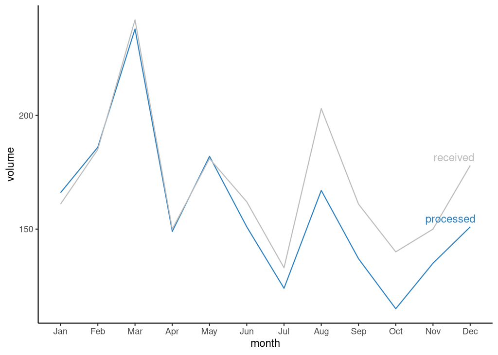

```r
ggplot(df_line_graph,aes(x=month,y = volume,colour = type,group = type)) +
  geom_line() +
  theme_classic() +
  geom_text(data = data_labels,aes(label = type),hjust=0.9,vjust=-0.5) +
  scale_color_manual(values= c("#3182bd","#bdbdbd")) +   # change color of series
  theme(legend.position=("none"))
```

increase the thickness of series lines

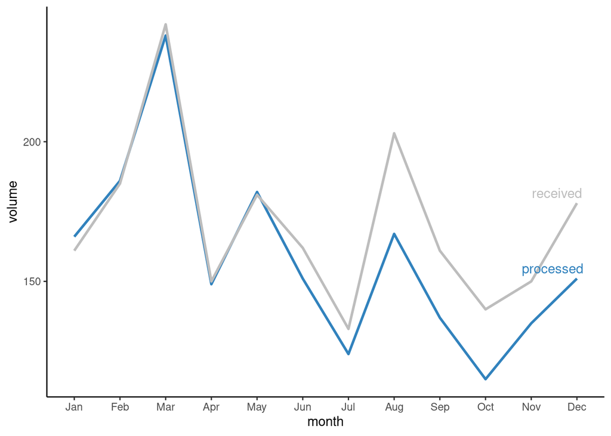

```r
ggplot(df_line_graph,aes(x=month,y = volume,colour = type,group = type)) +
  geom_line(size=1) +  # increase line size
  theme_classic() +
  geom_text(data = data_labels,aes(label = type),hjust=0.9,vjust=-0.5) +
  scale_color_manual(values= c("#3182bd","#bdbdbd")) +
  theme(legend.position=("none"))
```

change the color of the axis lines to grey

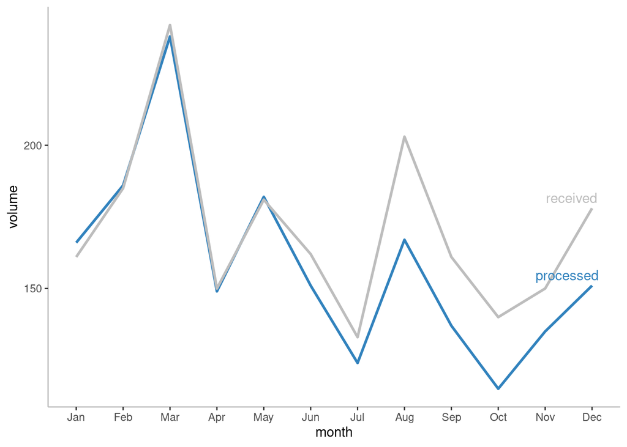

```r
ggplot(df_line_graph,aes(x=month,y = volume,colour = type,group = type)) +
  geom_line(size=1) +
  theme_classic() +
  geom_text(data = data_labels,aes(label = type),hjust=0.9,vjust=-0.5) +
  scale_color_manual(values= c("#3182bd","#bdbdbd")) +
  theme(legend.position=("none"),axis.line = element_line(color = "#bdbdbd")) # change axis line color
```

Change the color of the axis ticks to grey.

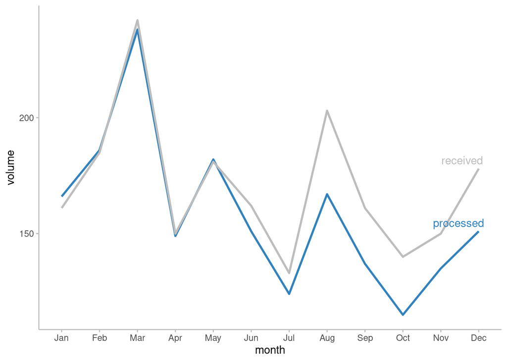

```r
ggplot(df_line_graph,aes(x=month,y=volume,colour=type,group=type)) +
  geom_line(size=1) +
  theme_classic() +
  geom_text(data=data_labels,aes(label=type),hjust=0.9,vjust=-0.5) +
  scale_color_manual(values=c("#3182bd","#bdbdbd")) +
  theme(legend.position=("none"),
        axis.line=element_line(color="#bdbdbd"),
        axis.ticks=element_line(color="#bdbdbd") # change axis tick color
  )
```

change the color of the axis labels to grey

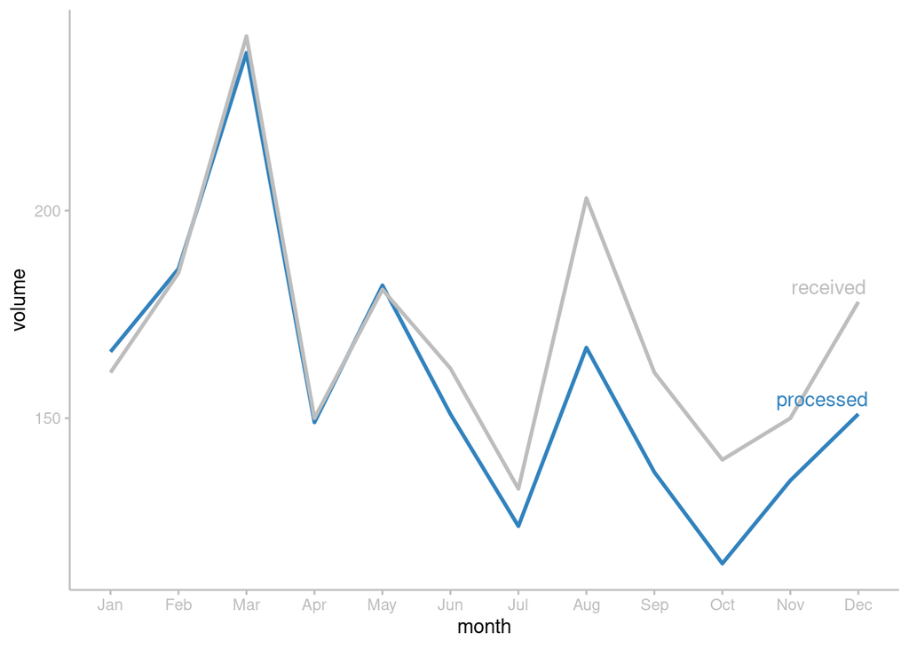

```r
ggplot(df_line_graph,aes(x=month,y=volume,colour=type,group=type)) +
  geom_line(size=1) +
  theme_classic() +
  geom_text(data=data_labels,aes(label=type),hjust=0.9,vjust=-0.5) +
  scale_color_manual(values=c("#3182bd","#bdbdbd")) +
  theme(legend.position=("none")
        ,axis.line=element_line(color="#bdbdbd")
        ,axis.ticks=element_line(color="#bdbdbd")
        ,axis.text=element_text(color="#bdbdbd")  # axis label color
  )
```

change the color of the axis titles to grey

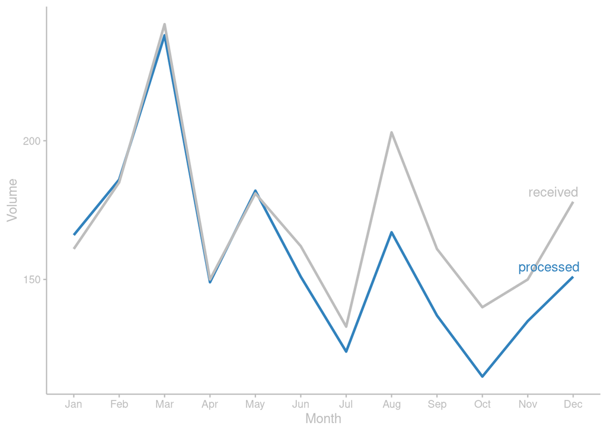

```r
ggplot(df_line_graph,aes(x=month,y = volume,colour = type,group = type)) +
  geom_line(size=1) +
  theme_classic() +
  geom_text(data=data_labels,aes(label = type),hjust=0.9,vjust=-0.5) +
  scale_color_manual(values= c("#3182bd","#bdbdbd")) +
  labs(x='Month',y='Volume') +  # add labels
  theme(legend.position=("none")
        ,axis.line = element_line(color = "#bdbdbd")
        ,axis.ticks = element_line(color = "#bdbdbd")
        ,axis.text = element_text(color = "#bdbdbd")
        ,axis.title = element_text(color = "#bdbdbd")  # axis titles
  )
```